# Slab + interval stats and geoms

### Mashups with Correll and Gleicher-style gradients

We can also take advantage of the fact that all slabinterval stats also supply `cdf` and `pdf` aesthetics to create charts that make use of both the CDF and the PDF in their aesthetic mappings. For example, we could create [Correll & Gleicher](https://doi.org/10.1109/TVCG.2014.2346298)-style gradient plots by fading the tails outside of the 95% interval in proportion to $|1 - 2F(x)|$ (where $F(x)$ is the CDF):

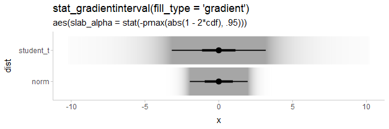

```r
priors %>%
  ggplot(aes(y = dist, xdist = dist, args = args)) +
  stat_gradientinterval(aes(slab_alpha = stat(-pmax(abs(1 - 2*cdf), .95))),
    fill_type = "gradient"
  ) +
  scale_slab_alpha_continuous(guide = "none") +
  ggtitle(
    "stat_gradientinterval(fill_type = 'gradient')",
    "aes(slab_alpha = stat(-pmax(abs(1 - 2*cdf), .95)))"
  )
```

We could also do a mashup of faded-tail gradients with violin plots by starting with an eye plot and then using the generated `cdf` aesthetic to fade the tails, producing plots like those in [Helske *et al.*](https://arxiv.org/abs/2002.07671):

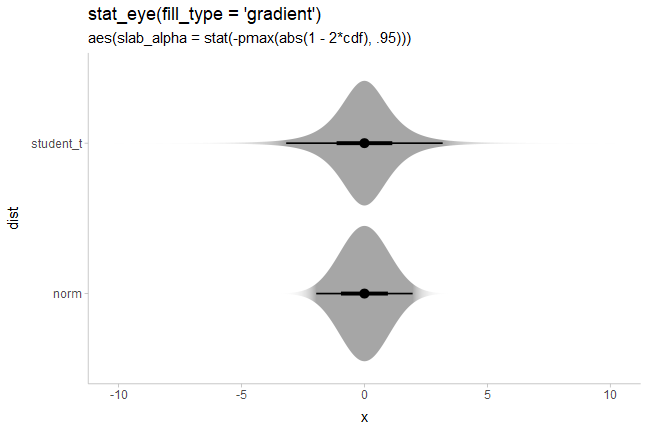

```r
priors %>%
  ggplot(aes(y = dist, xdist = dist, args = args)) +
  stat_eye(aes(slab_alpha = stat(-pmax(abs(1 - 2*cdf), .95))), fill_type = "gradient") +
  scale_slab_alpha_continuous(guide = "none") +
  ggtitle(
    "stat_eye(fill_type = 'gradient')",
    "aes(slab_alpha = stat(-pmax(abs(1 - 2*cdf), .95)))"
  )
```

A related idea is one from [Tukey](https://doi.org/10.1080/00031305.1986.10475361): rather than visually emphasizing where a value is likely, emphasize where it is *unlikely*. While Tukey used a visual representation showing both pointwise and simultaneous intervals, for this example we will do something a bit different, inverting the faded-tails function from Correll & Gleicher to create bars that “block out” the regions of low likelihood:

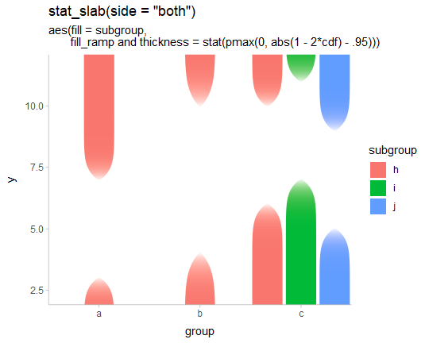

```r
dist_df %>%
  ggplot(aes(x = group, ydist = dist_normal(mean, sd), fill = subgroup)) +
  stat_slab(
    aes(
      thickness = stat(pmax(0, abs(1 - 2*cdf) - .95)),
      fill_ramp = stat(pmax(0, abs(1 - 2*cdf) - .95))
    ),
    side = "both", position = "dodge", fill_type = "gradient"
  ) +
  labs(
    title = 'stat_slab(side = "both")',
    subtitle = paste0(
      "aes(fill = subgroup,\n       ",
      "fill_ramp and thickness = stat(pmax(0, abs(1 - 2*cdf) - .95)))"
    )
  ) +
  guides(fill_ramp = "none") +
  coord_cartesian(expand = FALSE)
```

Thanks to a tweet from [Jessica Hullman](https://twitter.com/JessicaHullman/status/1366945872630714368?s=20) that inspired the idea.

### Densities filled according to intervals

Another common chart type involves filling in the interior of a halfeye plot according to some intervals. We can again use the fact that slabinterval stats auto-calculate both the PDF and CDF of a distribution as statistics. We can then use the `cut_cdf_qi()` function, which labels points in a CDF according to which quantile interval they fall into, to determine the fill color:

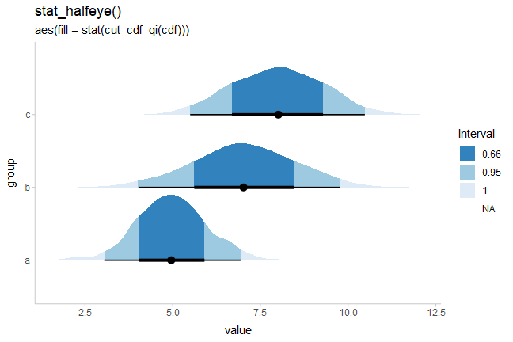

```r
df %>%
  ggplot(aes(y = group, x = value)) +
  stat_halfeye(aes(fill = stat(cut_cdf_qi(cdf)))) +
  scale_fill_brewer(direction = -1) +
  labs(
    title = "stat_halfeye()",
    subtitle = "aes(fill = stat(cut_cdf_qi(cdf)))",
    fill = "Interval"
  )
```

Like `point_interval()`, `cut_cdf_qi()` takes a `.width` parameter to define the intervals, with a default of `c(.66, .95, 1)`. The final `1` is necessary to show the full density; to cut off the tails of the density you can omit it.

Like ggplot scales, `cut_cdf_qi()` also takes a `labels` parameter to define the labels of the intervals (or to provide a function to define the labels, such as a formatting function like `scales::percent_format()`). Let’s modify the intervals to show the 50%, 80%, and 95% intervals, omitting the tails of the density and reformatting the interval labels to use percentages. We can also use `na.translate = FALSE` to drop the unnecessary `NA` level from the fill scale:

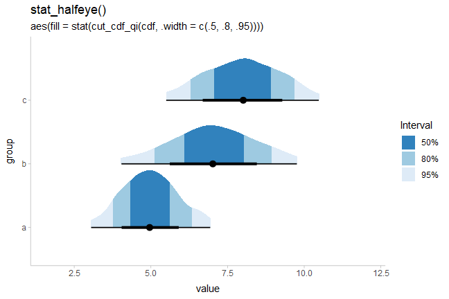

```r
df %>%
  ggplot(aes(y = group, x = value)) +
  stat_halfeye(aes(fill = stat(cut_cdf_qi(
    cdf,
    .width = c(.5, .8, .95),
    labels = scales::percent_format()
  )))) +
  scale_fill_brewer(direction = -1, na.translate = FALSE) +
  labs(
    title = "stat_halfeye()",
    subtitle = "aes(fill = stat(cut_cdf_qi(cdf, .width = c(.5, .8, .95))))",
    fill = "Interval"
  )
```

### Using color ramps for `fill` and `color` aesthetics

`ggdist` supplies `color_ramp` (or `colour_ramp`) and `fill_ramp` aesthetics which can be used to vary (“ramp”) the outline or fill colors smoothly from a base color (default `"white"`) to whatever color the geometry would otherwise have.

Taking the above example with `cut_cdf_qi()`, we could use the `fill_ramp` aesthetic instead of the `fill` aesthetic to set the slab color based on the interval it is in. We could then vary the base fill color separately from the interval based on another column in the original data table, such as the `subgroup` column:

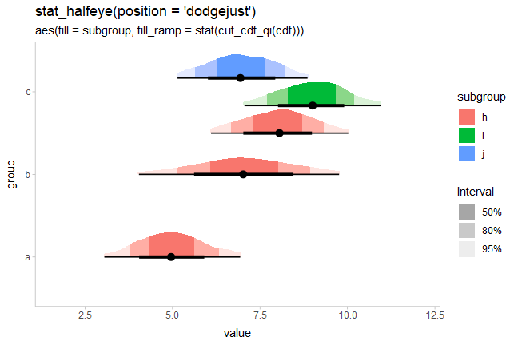

```r
df %>%
  ggplot(aes(y = group, x = value)) +
  stat_halfeye(
    aes(
      fill = subgroup,
      fill_ramp = stat(cut_cdf_qi(
        cdf,
        .width = c(.5, .8, .95),
        labels = scales::percent_format()
      ))
    ),
    # NOTE: we use position = "dodgejust" (a dodge that respects the
    # justification of intervals relative to slabs) instead of
    # position = "dodge" here because it ensures the topmost slab does
    # not extend beyond the plot limits
    position = "dodgejust",
  ) +
  # a range from 1 down to 0.2 ensures the fill goes dark to light inside-out
  # and doesn't get all the way down to white (0) on the lightest color
  scale_fill_ramp_discrete(range = c(1, 0.2), na.translate = FALSE) +
  labs(
    title = "stat_halfeye(position = 'dodgejust')",
    subtitle = "aes(fill = subgroup, fill_ramp = stat(cut_cdf_qi(cdf)))",
    fill_ramp = "Interval"
  )
```

We could similarly use `stat_interval()` with the `color_ramp` aesthetic to vary subgroup color separately from the whiteness of the intervals. Here, `level` is a variable generated by all stats in the `stat_slabinterval()` family which contains the level of the generated intervals, as an ordered factor.

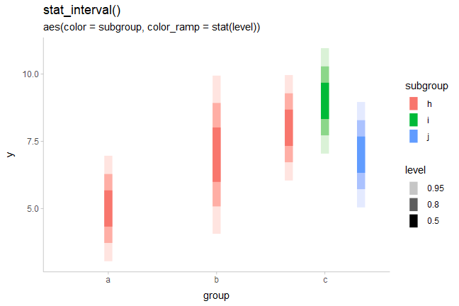

```r
dist_df %>%
  ggplot(aes(x = group, ydist = dist_normal(mean, sd), color = subgroup)) +
  stat_interval(aes(color_ramp = stat(level)), position = "dodge") +
  labs(
    title = "stat_interval()",
    subtitle = "aes(color = subgroup, color_ramp = stat(level))"
  )
```

See `help("scale_color_ramp")` for more information on the color ramp aesthetics/scales.

### Creating ridge plots

When plotting densities (as in `stat_halfeye()`, `stat_slab()`, etc) it can be useful to overplot many densities simultaneously, an approach sometimes called *ridge plots* (e.g. as in the [ggridges](https://wilkelab.org/ggridges/) package). This can be done by setting `scale` or `height` to a value greater than 1. Setting `height` is often the best approach as it will correctly adjust plot boundaries (unless you need to use `position = "dodge"`, in which case you should use `scale` and adjust plot boundaries manually).

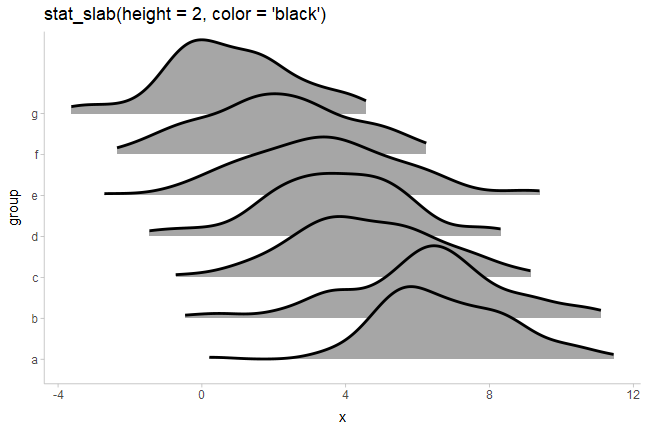

```r
set.seed(1234)

ridges_df = data.frame(
  group = letters[7:1],
  x = rnorm(700, mean = 1:7, sd = 2)
)

ridges_df %>%
  ggplot(aes(y = group, x = x)) +
  stat_slab(height = 2, color = "black") +
  ggtitle("stat_slab(height = 2, color = 'black')")
```

Depending on if it makes sense for your data (for example, if the scale is unbounded), you may also wish to adjust the `trim` parameter, which by default restricts the density estimator to 0 outside of the range of the data. Setting `trim` to `FALSE` will ensure the densities smoothly go down to 0. Combining this with `expand = TRUE` will make each slab expand itself to the limits of the `x` axis.

We’ll use `trim` and `expand` along with a combination of `fill` and `fill_ramp` to give each group on the y axis a different color and to vary the fill along the `x` axis in a way that provides a “softer” form of region of practical equivalence:

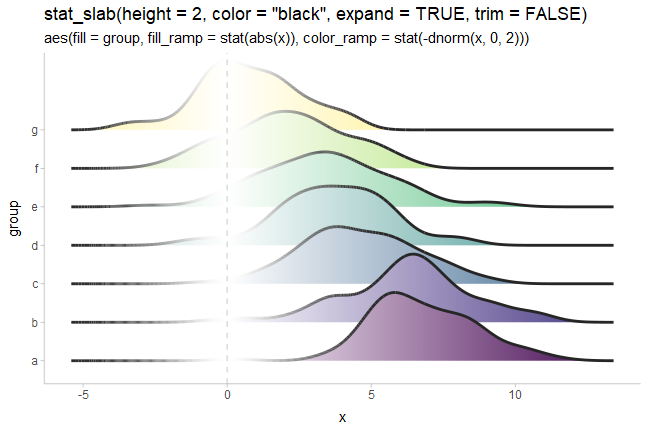

```r
ridges_df %>%
  ggplot(aes(
    y = group, x = x,
    fill = group, fill_ramp = stat(abs(x)),
    color_ramp = stat(-dnorm(x, 0, 2))
  )) +
  stat_slab(
    height = 2, color = "gray15",
    expand = TRUE, trim = FALSE,
    fill_type = "gradient",
    show.legend = FALSE
  ) +
  geom_vline(xintercept = 0, color = "gray85", linetype = "dashed") +
  ggtitle(
    'stat_slab(height = 2, color = "black", expand = TRUE, trim = FALSE)',
    'aes(fill = group, fill_ramp = stat(abs(x)), color_ramp = stat(-dnorm(x, 0, 2)))'
  ) +
  scale_fill_viridis_d()
```

We use a tighter ramp on `color` compared to `fill` (via `-dnorm()` instead of `abs()`) because we want the outlines to quickly ramp back to black outside of 0 so that they have sufficient contrast against the slabs when they overlap.

### Varying side, scale, and justification within geoms

The `side`, `scale`, and `justification` parameters can also be varied within all geoms in the `geom_slabinterval()` family, allowing (for example) different groups to hang above or below the interval:

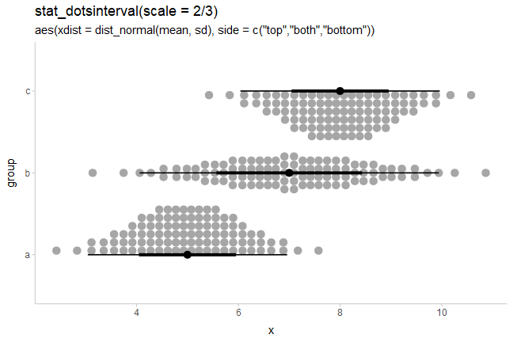

```r
dist_df %>%
  filter(subgroup == "h") %>%
  mutate(side = c("top", "both", "bottom")) %>%
  ggplot(aes(y = group, xdist = dist_normal(mean, sd), side = side)) +
  stat_dotsinterval(scale = 2/3) +
  labs(
    title = 'stat_dotsinterval(scale = 2/3)',
    subtitle = 'aes(xdist = dist_normal(mean, sd), side = c("top","both","bottom"))'
  ) +
  coord_cartesian()
```

### Multiple slabs and intervals in composite plots

Sometimes you may want to include multiple different types of slabs in the same plot in order to take advantage of the features each slab type provides. For example, people often combine densities with dotplots to show the underlying datapoints that go into a density estimate, creating so-called “rain cloud” plots.

To use multiple slab geometries together, you can use the `side` parameter to change which side of the interval a slab is drawn on and set the `scale` parameter to something around `0.5` (by default it is `0.9`) so that the two slabs do not overlap. Geoms can also be dodged together, as in this example using densities with quantile dotplots in subgroups. This example also shows how `stat_pointinterval()` can be repurposed to be used with other geoms; here to replace points with labels (the idea of replacing points with labels comes from Brenton Wiernik).

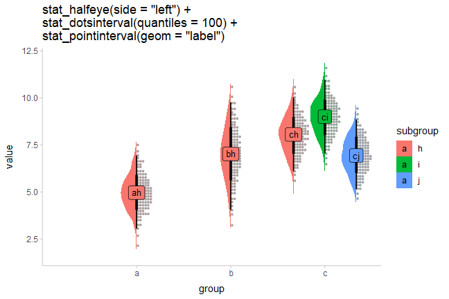

```r
df %>%
  ggplot(aes(x = group, y = value, fill = subgroup)) +
  stat_slab(side = "left", scale = 0.5, position = "dodge") +
  stat_dotsinterval(scale = 0.5, quantiles = 100, position = "dodge") +
  stat_pointinterval(
    geom = "label",
    aes(label = paste0(group, subgroup)),
    .width = .5,  # set to a scalar to draw only one label instead of two
    position = position_dodge(width = 1),
    size = 3.5
  ) +
  labs(title = paste0(
    'stat_halfeye(side = "left") +\n',
    'stat_dotsinterval(quantiles = 100) +\n',
    'stat_pointinterval(geom = "label")'
  ))
```

When constructing composite plots it may be useful to position the slab and interval parts of the geometry separately. While some relative positioning of these geometries is supported by manipulating the `justification` parameter, if you want complete, separate control over positioning of intervals versus slabs, the simplest approach can be to specify those geometries separately.

For example, the following uses a separate specification of a `stat_slab()` and a `stat_pointinterval()` instead of a combined `stat_slabinterval()` in order to use `position_dodge()` on the intervals but not the slabs:

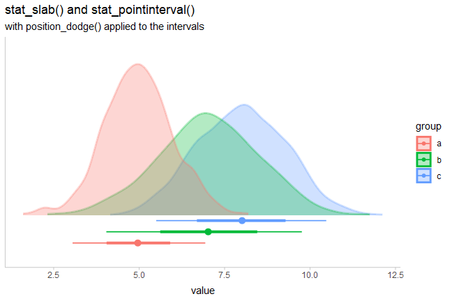

```r
df %>%
  ggplot(aes(fill = group, color = group, x = value)) +
  stat_slab(alpha = .3) +
  stat_pointinterval(position = position_dodge(width = .4, preserve = "single")) +
  labs(
    title = "stat_slab() and stat_pointinterval()",
    subtitle = "with position_dodge() applied to the intervals",
    y = NULL
  ) +
  scale_y_continuous(breaks = NULL)
```

(Thanks to Brenton Wiernik for [this example](https://github.com/mjskay/ggdist/issues/27#issuecomment-725578437).)